# Homework 1 - Henry Schliebe

# Step 1

```r
library(MASS)
data(Boston)
str(Boston)
```

```
## 'data.frame':    506 obs. of  14 variables:
##  $ crim   : num  0.00632 0.02731 0.02729 0.03237 0.06905 ...
##  $ zn     : num  18 0 0 0 0 0 12.5 12.5 12.5 12.5 ...
##  $ indus  : num  2.31 7.07 7.07 2.18 2.18 2.18 7.87 7.87 7.87 7.87 ...
##  $ chas   : int  0 0 0 0 0 0 0 0 0 0 ...
##  $ nox    : num  0.538 0.469 0.469 0.458 0.458 0.458 0.524 0.524 0.524 0.524 ...
##  $ rm     : num  6.58 6.42 7.18 7 7.15 ...
##  $ age    : num  65.2 78.9 61.1 45.8 54.2 58.7 66.6 96.1 100 85.9 ...
##  $ dis    : num  4.09 4.97 4.97 6.06 6.06 ...
##  $ rad    : int  1 2 2 3 3 3 5 5 5 5 ...
##  $ tax    : num  296 242 242 222 222 222 311 311 311 311 ...
##  $ ptratio: num  15.3 17.8 17.8 18.7 18.7 18.7 15.2 15.2 15.2 15.2 ...
##  $ black  : num  397 397 393 395 397 ...
##  $ lstat  : num  4.98 9.14 4.03 2.94 5.33 ...
##  $ medv   : num  24 21.6 34.7 33.4 36.2 28.7 22.9 27.1 16.5 18.9 ...
```

The Boston data set includes information about housing values in the suburbs of Boston. Each entry has 14 columns or attributes including crim (the per capita crime rate by town), rm (the average number of rooms per dwelling), and medv (the median value of owner occupied homes in /$1000s). Each observation/row represents a neighborhood in Boston.

# Step 2

```r
head(Boston, n=5)
```

|  | crim | zn | indus | chas | nox | rm | age | dis | rad | tax | ptratio | black | lstat | medv |
| --- | --- | --- | --- | --- | --- | --- | --- | --- | --- | --- | --- | --- | --- | --- |
| 1 | 0.00632 | 18 | 2.31 | 0 | 0.538 | 6.575 | 65.2 | 4.0900 | 1 | 296 | 15.3 | 396.90 | 4.98 | 24.0 |
| 2 | 0.02731 | 0 | 7.07 | 0 | 0.469 | 6.421 | 78.9 | 4.9671 | 2 | 242 | 17.8 | 396.90 | 9.14 | 21.6 |
| 3 | 0.02729 | 0 | 7.07 | 0 | 0.469 | 7.185 | 61.1 | 4.9671 | 2 | 242 | 17.8 | 392.83 | 4.03 | 34.7 |
| 4 | 0.03237 | 0 | 2.18 | 0 | 0.458 | 6.998 | 45.8 | 6.0622 | 3 | 222 | 18.7 | 394.63 | 2.94 | 33.4 |
| 5 | 0.06905 | 0 | 2.18 | 0 | 0.458 | 7.147 | 54.2 | 6.0622 | 3 | 222 | 18.7 | 396.90 | 5.33 | 36.2 |

```r
tail(Boston, n=2)
```

|  | crim | zn | indus | chas | nox | rm | age | dis | rad | tax | ptratio | black | lstat | medv |
| --- | --- | --- | --- | --- | --- | --- | --- | --- | --- | --- | --- | --- | --- | --- |
| 505 | 0.10959 | 0 | 11.93 | 0 | 0.573 | 6.794 | 89.3 | 2.3889 | 1 | 273 | 21 | 393.45 | 6.48 | 22.0 |
| 506 | 0.04741 | 0 | 11.93 | 0 | 0.573 | 6.030 | 80.8 | 2.5050 | 1 | 273 | 21 | 396.90 | 7.88 | 11.9 |

```r
Boston[5,]
```

|  | crim | zn | indus | chas | nox | rm | age | dis | rad | tax | ptratio | black | lstat | medv |
| --- | --- | --- | --- | --- | --- | --- | --- | --- | --- | --- | --- | --- | --- | --- |
| 5 | 0.06905 | 0 | 2.18 | 0 | 0.458 | 7.147 | 54.2 | 6.0622 | 3 | 222 | 18.7 | 396.9 | 5.33 | 36.2 |

```r
head(Boston[1], n=3)
```

|  | crim |
| --- | --- |
| 1 | 0.00632 |
| 2 | 0.02731 |
| 3 | 0.02729 |

```r
names(Boston)
```

```
##  [1] "crim"    "zn"      "indus"   "chas"    "nox"     "rm"      "age"
##  [8] "dis"     "rad"     "tax"     "ptratio" "black"   "lstat"   "medv"
```

# Step 3

```r
mean(Boston[,1])
```

```
## [1] 3.613524
```

```r
median(Boston[,1])
```

```
## [1] 0.25651
```

```r
range(Boston[,1])
```

```
## [1]  0.00632 88.97620
```

# Step 4

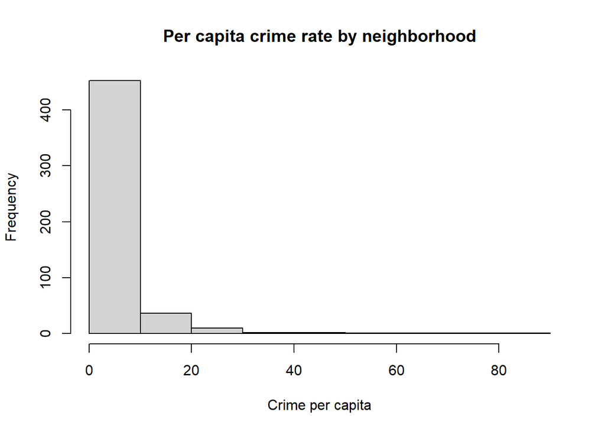

```r
hist(Boston$crim, main="Per capita crime rate by neighborhood", xlab="Crime per capita", ylab="Frequency")
```

This histogram tells us that the vast majority of the neighborhoods have a crim value between 0 and 10 which is the per capita crime rate. This means that there is a very low crime rate in most of the towns in Boston (as most of these values arent even greater than 1).

# Step 5

```r
cor(Boston$crim, Boston$medv)
```

```
## [1] -0.3883046
```

This value tells us that there is a negative correlation between the two variables. The crime column could definitely be useful for predicting a median value. For example, as the crime rate goes up, the house values go down.

# Step 6

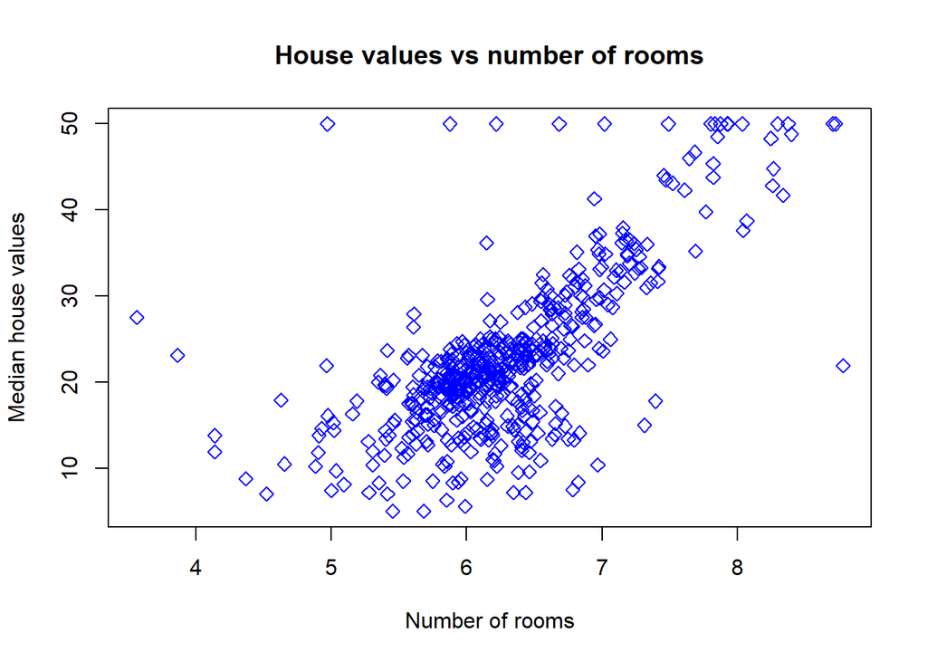

```r
plot(Boston$medv~Boston$rm, main="House values vs number of rooms", xlab="Number of rooms", ylab="Median house values", col="blue", pch=5)
```

```r
cor(Boston$medv, Boston$rm)
```

```
## [1] 0.6953599
```

This graph clearly shows a positive correlation between these two variables such that the median house values increase as the number of rooms increases.

# Step 7

```r
is.factor(Boston$chas)
```

```
## [1] FALSE
```

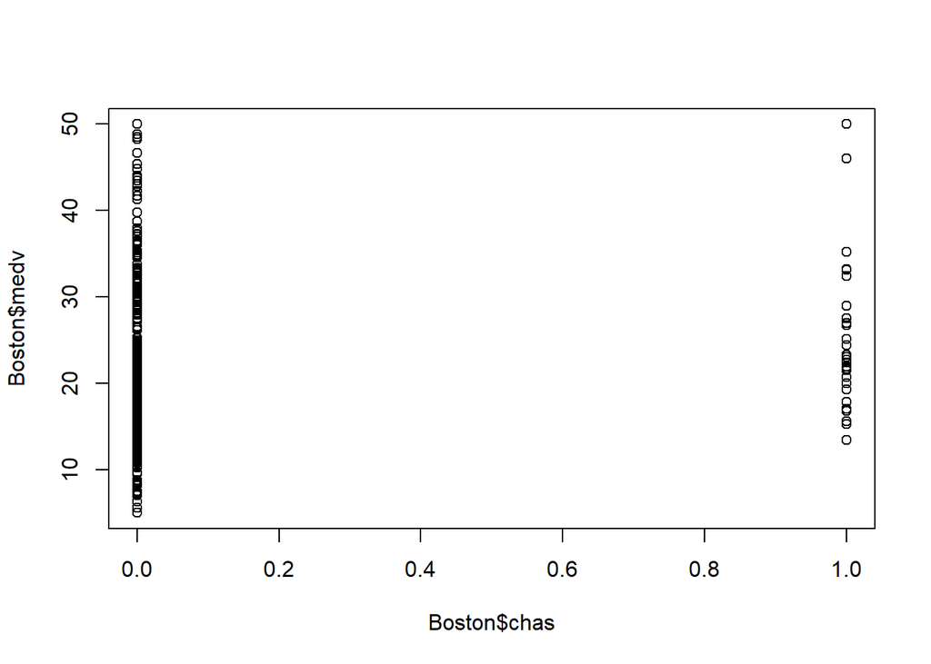

```r
plot(Boston$medv~Boston$chas)
```

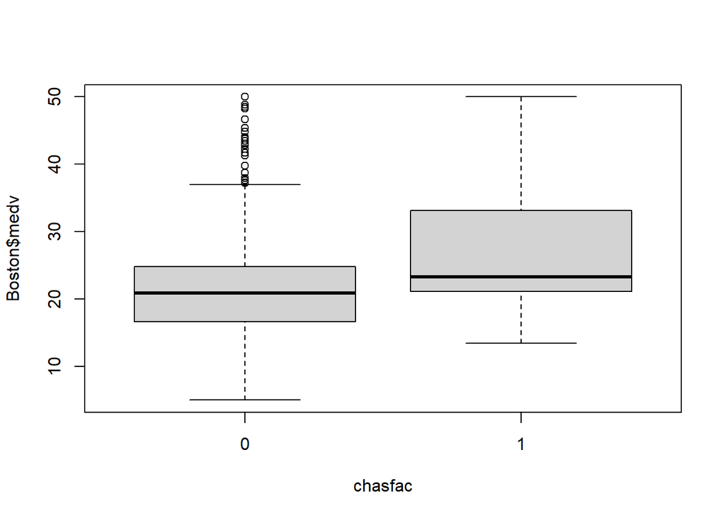

```r
chasfac <- factor(Boston$chas)
plot(Boston$medv~chasfac)
```

The second graph with the factored variable makes it looks a lot neater in the form of a box plot while the first graph is just a raw graph of the data. Chas is the Charles River dummy variable. Chas is 1 if the neighborhood bounds the river, 0 otherwise.

# Step 8

```r
typeof(Boston$rad)
```

```
## [1] "integer"
```

```r
summary(Boston$rad)
```

```
##    Min. 1st Qu.  Median    Mean 3rd Qu.    Max.
##   1.000   4.000   5.000   9.549  24.000  24.000
```

```r
unique(Boston$rad)
```

```
## [1]  1  2  3  5  4  8  6  7 24
```

```r
sumrad <- sum(Boston$rad==24)
percentage <- sumrad/nrow(Boston)*100
percentage
```

```
## [1] 26.08696
```

Rad is of the integer type. Summary gives us the minimum, 1st quarter, median, mean, 3rd quarter and maximum values. Unique shows us every value of rad similar to distinct in sql queries. 26.09% of the neighborhoods have a rad value of 24.

# Step 9

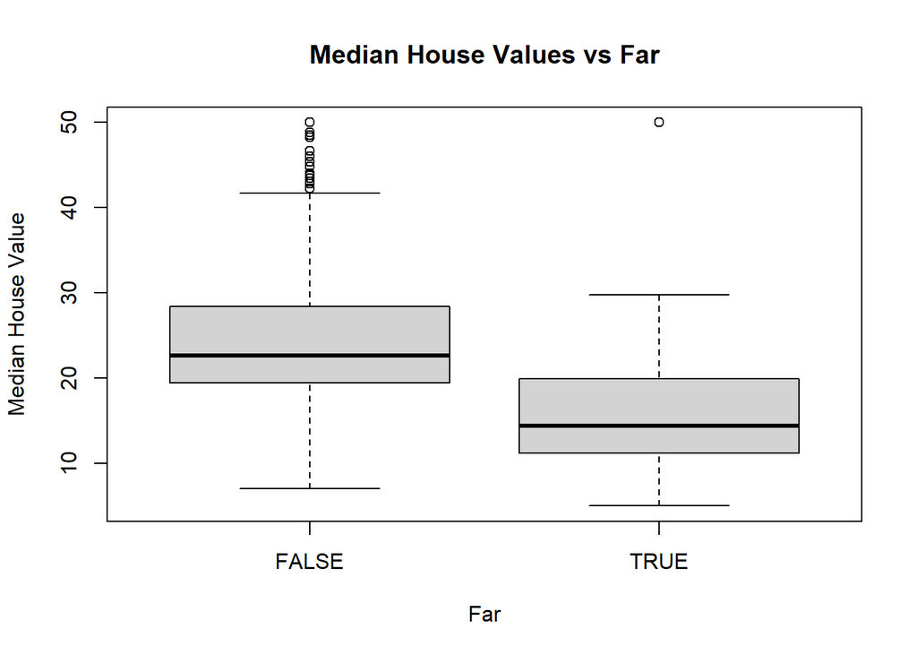

```r
far <- ifelse(Boston$rad==24, TRUE, FALSE)
far <- factor(far)
plot(Boston$medv~far, xlab="Far", ylab="Median House Value", main="Median House Values vs Far")
```

This plot shows us that most houses are cheaper in neighborhoods that are farther away from highways.

# Step 10

```r
summary(Boston[,c(1,6,13,14)])
```

```
##       crim                rm            lstat            medv
##  Min.   : 0.00632   Min.   :3.561   Min.   : 1.73   Min.   : 5.00
##  1st Qu.: 0.08205   1st Qu.:5.886   1st Qu.: 6.95   1st Qu.:17.02
##  Median : 0.25651   Median :6.208   Median :11.36   Median :21.20
##  Mean   : 3.61352   Mean   :6.285   Mean   :12.65   Mean   :22.53
##  3rd Qu.: 3.67708   3rd Qu.:6.623   3rd Qu.:16.95   3rd Qu.:25.00
##  Max.   :88.97620   Max.   :8.780   Max.   :37.97   Max.   :50.00
```

```r
rowmaxmedv <- which.max(Boston[,14])
str(Boston[rowmaxmedv,c(1,6,13,14)])
```

```
## 'data.frame':    1 obs. of  4 variables:
##  $ crim : num 1.46
##  $ rm   : num 7.49
##  $ lstat: num 1.73
##  $ medv : num 50
```

The most expensive neighborhood in Boston also has the lowest lstat variable, meaning the people living in the most expensive houses are also of high status. The crime isn’t lowest in the most expensive neighborhood but its still pretty low. The most expensive houses also have a high number of rooms.